# Introduction à la modélisation statistique bayésienne

Ladislas Nalborczyk & Thierry Phénix

### Planning

## Cours

Cours 1: Introduction à l'inférence bayésienne

Cours 2: Modèle beta-binomial

Cours 3 & 4: Modèle de régression linéaire

Cours 5: Markov Chain Monte Carlo

**Cours 6: Modèle linéaire généralisé**

Cours 7: Comparaison de modèles

Cours 8: Modèles multi-niveaux

Cours 9: Introduction à `brms`

Cours 10: Data Hackaton

## Plan

- **Introduction**
- Régression logistique
- Régression binomiale aggrégée

### Introduction

### LE MODÈLE GAUSSIEN LINÉAIRE

**\( \rightarrow~ \) Le modèle gaussien que l'on a vu jusqu'ici se caractérise par :**

- Les résidus sont distribués normalement
- Les prédicteurs agissent sur la moyenne de cette distibution
- La moyenne suit un modèle linéaire ou multi-linéaire

> \[ \begin{align} y_{i} &\sim \mathrm{Normal}(\mu_{i},\sigma) \\ \mu_{i}&= \alpha + \beta_X x_{i} + \beta_Y Y_{i} \\ \end{align} \]

**\( \rightarrow~ \) Cette modélisation induit deux contraintes :**

- les données observées sont définies sur un espace continu
- Cet espace n'est pas borné

### Introduction

### LE MODÈLE BETA-BINOMIAL

**\( \rightarrow~ \) Le modèle Beta-Binomial se caractérise par :**

- les données observées sont binaires 0/1 ou le résultat d'une somme d'observations binaires
- la probabilité de succès (obtenir 1) se caractérise par une distribution Beta
- la probabilité de succès (obtenir 1) ne dépend d'aucun prédicteur

> \[ \begin{align} w &\sim \mathrm{Binomial}(n,p) \\ p &\sim \mathrm{Beta}(a,b) \end{align} \]

**\( \rightarrow~ \) Cette modélisation induit deux contraintes :**

- les données observées sont définies sur un espace discret
- Cet espace est borné

## QUESTION : Comment ajouter des prédicteurs à ce modèle ?

### Introduction

### LE MODÈLE LINÉAIRE GÉNÉRALISÉ (GLM)

**\( \rightarrow~ \) Objectifs :**

- Rendre compte de données discrètes générées par un unique processus
- Introduire des prédicteurs dans le modèle

> \[ \begin{align} y_{i} &\sim \mathrm{Binomial}(n,p_{i}) \\ f(p_{i}) &= \alpha + \beta~x_{i} \\ \end{align} \]

**\( \rightarrow~ \) Deux changement par rapport au modèle gaussien :**

- L'utilisation d'une distribution de probabilité binomiale
- Le modèle linéaire ne sert plus à décrire directement un des paramètres de la distribution, mais une fonction de ce paramètre

### Introduction

### GLM : Utilisation d'une distribution de probabilité binomiale

**\( \rightarrow~ \) Cette distribution maximise l'entropie lorsque :**

- Les données observées proviennent de \( n \) essais indépendants
- Avec une espérance d'apparition de \( np \)

Cette distribution se caractérise par deux paramètres, \( n \) qui est le nombre d'essai et \( p \) qui est la probabilité de succès  
La moyenne \( np \) est le produit de ces deux paramètres.

**\( \rightarrow~ \) Comment modéliser l'action des prédicteurs ?**

- Le plus souvent n est connu
- Les prédicteurs agissent sur p (modèle linéaire)

### Introduction

### GLM : Fonction de lien

> Les fonctions de lien ont pour tâche de mettre en correspondance l'espace d'un modèle linéaire (non borné) avec l'espace d'un paramètre.

**\( \rightarrow~ \) La fonction Logit du GLM binomial :**

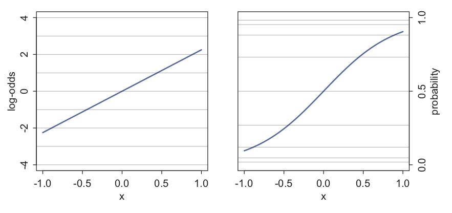

### Introduction

### GLM : Fonction de lien

> Les fonctions de lien (inverse) on pour tâche de mettre en correspondance l'espace d'un modèle linéaire (non borné) avec l'espace d'un paramètre.$

**\( \rightarrow~ \) La fonction Logit du GLM binomial :**

- La définition de la fonction logit (on parle de log-odds) :

\[ logit(p_i) = log\left( \frac{p_i}{1-p_i} \right) \]

- Les chances (odds) d'un évènement sont simplement la probabilité qu'il arrive sur la probabilité qu'il n'arrive pas :

\[ log\left( \frac{p_i}{1-p_i} \right) = \alpha + \beta~x_i \]

- Pour retrouver la probabilité d'un événement, il faut utiliser la fonction de **lien inverse**

\[ p_i = \frac{exp(\alpha + \beta~x_i)}{1 + exp(\alpha + \beta~x_i)} \]

On parle de fonction **LOGISTIQUE** ou de fonction **LOGIT-INVERSE**

### Introduction

### GLM : Problèmes induits par la fonction de lien

Ces fonctions de lien posent des problèmes d'interprétation :

> 1. Un changement d'une unité sur un prédicteurs n'a plus un effet constant sur la probabilité mais la modifie plus ou moins en fonction de son éloignement à l'origine.
- En x = 0, une augmentation d'une demi-unité (x = 0.5) se traduit par une augmentation d ela probabilité de 0.25
- Puis, chaque augmentation d'une demi-unité se traduit par une augmentation de p de plus en plus petite

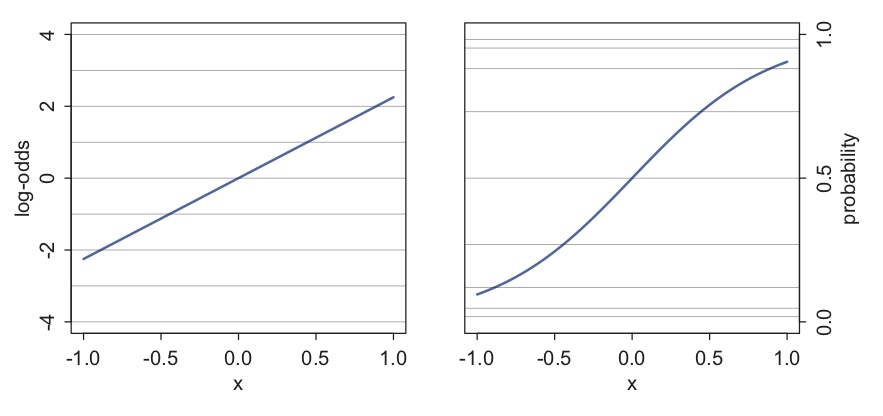

### Introduction

### GLM : Problèmes induits par la fonction de lien

Ces fonctions de lien posent des problèmes d'interprétation :

> 1. Les GLMs forcent chaque prédicteur à interagir avec lui même et à interagir avec TOUS les autres prédicteurs, même si les interactions ne sont pas explicites.
- Dans un modèle gaussien, Le taux de changement de y en fonction de x est : \( \partial(\alpha + \beta x)~/~\partial x = \beta \)
- Dans un GLM binomial, la probabilité d'un événement est donné par la fonction logistique :

\[ p_i = \frac{exp(\alpha + \beta~x_i)}{1 + exp(\alpha + \beta~x_i)} \]

- Dans un GLM binomial, Le taux de changement de p en fonction du prédicteur x est :

\[ \frac{\partial p}{\partial x} = \frac{\beta}{2(1 + cosh(\alpha + \beta~x)} \]

## On voit que la variation sur p due au prédicteur x est fonction du prédicteur x !

### Planning

## Cours

Cours 1: Introduction à l'inférence bayésienne

Cours 2: Modèle beta-binomial

Cours 3 & 4: Modèle de régression linéaire

Cours 5: Markov Chain Monte Carlo

**Cours 6: Modèle linéaire généralisé**

Cours 7: Comparaison de modèles

Cours 8: Modèles multi-niveaux

Cours 9: Introduction à `brms`

Cours 10: Data Hackaton

## Plan

- Introduction
- **Régression logistique**
- Régression binomiale aggrégée

### Régression logistique

### EXPÉRIENCE : La prosocialité chez le chimpanzé

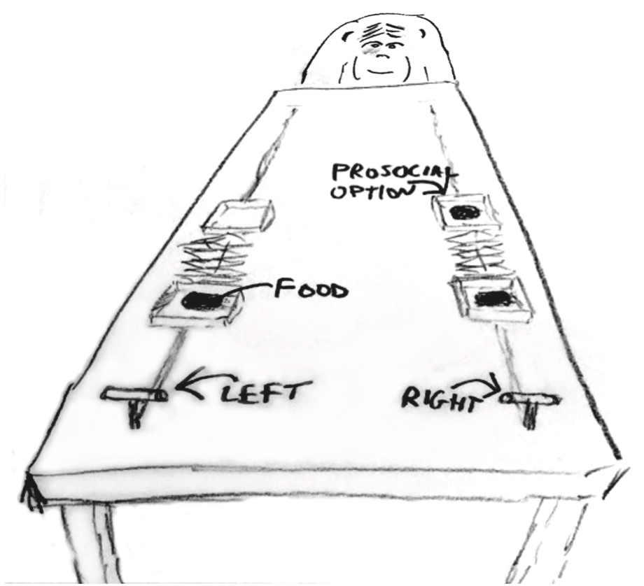

### Régression logistique

### DATA : “chimpanzees”

```r
# L'ordre est important pour utiliser la fonction map de rethinking...
library(tidyverse)
library(rethinking)
data(chimpanzees)
df1 <- chimpanzees
str(df1)
```

```
'data.frame':   504 obs. of  8 variables:
 $ actor       : int  1 1 1 1 1 1 1 1 1 1 ...
 $ recipient   : int  NA NA NA NA NA NA NA NA NA NA ...
 $ condition   : int  0 0 0 0 0 0 0 0 0 0 ...
 $ block       : int  1 1 1 1 1 1 2 2 2 2 ...
 $ trial       : int  2 4 6 8 10 12 14 16 18 20 ...
 $ prosoc_left : int  0 0 1 0 1 1 1 1 0 0 ...
 $ chose_prosoc: int  1 0 0 1 1 1 0 0 1 1 ...
 $ pulled_left : int  0 1 0 0 1 1 0 0 0 0 ...
```

- **pulled_left** : 1 lorsque le chimpanzé pousse le levier gauche, 0 sinon
- **prosoc_left** : 1 lorsque le levier gauche est associé à l'option prosociale, 0 sinon
- **condition** : 1 lorsqu'un paternaire est présent, 0 sinon

### Régression logistique

### LE PROBLÈME

On cherche à savoir si la présence d'un singe partenaire incite de chimpanzé à appuyer sur le levier gauche, lorsque celui-ci est dans la condition prosocial, c'est-à-dire lorsque deux repas sont disponibles du coté gauche.

### LES VARIABLES

- Observations (pulled_left) : Ce sont des variables de Bernouilli. Elles prennent comme valeur 0/1.

  Pas de distribution gaussienne!!!
- Prédicteur (prosoc_left) : La présence des deux plats incite-t-elle le singe à choisir ce levier ?
- Prédicteur (condition) : La présence d'un paternaire n'a aucune raison d'inciter le singe à choisir le levier gauche.

  En revanche, elle peut modifier son comportement lorsqu'il y a deux plats… **comportement prosocial** interaction

### Régression logistique

### MODÈLE - Théorique

> \[ \begin{align} L_{i} &\sim \mathrm{Binomial}(1, p_{i}) \\ logit(p_{i}) &= \alpha + (\beta_P +\beta_{PC}~C_{i})~ P_i\\ \alpha &\sim \mathrm{Normal}(0,10) \\ \beta_P &\sim \mathrm{Normal}(0,10) \\ \beta_{PC} &\sim \mathrm{Normal}(0,10) \\ \end{align} \]
- \( L_{i} \) indique si le singe a poussé le levier gauche 'pulled_left'

### Les données sont des 0/1 ?

- \( P_{i} \) indique si le coté gauche correspond au coté prosocial
- \( C_{i} \) indique la présence d'un partenaire

### Régression logistique

### MODÈLE - sans prédicteur

Avant d'implémenter de modèle complet, commençons par présenter le modèle sans prédicteur :

```r
mod1 <- map(alist(
    pulled_left ~ dbinom(1, p),
    logit(p) <- a,
    a ~ dnorm(0, 10) ),
    data = df1)
```

```r
precis(mod1)
```

```
  Mean StdDev 5.5% 94.5%
a 0.32   0.09 0.18  0.46
```

### Régression logistique

### MODÈLE - sans prédicteur

Interprétation :  
\( \rightarrow~~ \) L'intercept ne s'interprète pas directement, il est le log du rapport des distributions.  
Pour l'interpréter (et donc parler de p) il faut utiliser la fonction `logistic`

```r
logistic(c(0.32, 0.18, 0.46) )
```

```
[1] 0.5793243 0.5448789 0.6130142
```

> \( \longrightarrow~~ \) **Avant l'introduction d'un prédicteur, il semblerait que les singes aient plus tendance à appuyer sur le levier gauche**

### Régression logistique

### MODÈLE - avec un prédicteur

```r
mod2 <- map(alist(
    pulled_left ~ dbinom(1, p),
    logit(p) <- a + bp*prosoc_left,
    a ~ dnorm(0, 10),
    bp ~ dnorm(0, 10) ),
    data = df1
    )
```

### MODÈLE - Complet

```r
mod3 <- map(alist(
    pulled_left ~ dbinom(1, p),
    logit(p) <- a + (bp + bpC * condition) * prosoc_left,
    a ~ dnorm(0, 10),
    bp ~ dnorm(0, 10),
    bpC ~ dnorm(0, 10) ),
    data = df1
    )
```

### Régression logistique

### Comparaison des trois modèles avec la méthode WAIC

```r
compare(mod1, mod2, mod3)
```

```
      WAIC pWAIC dWAIC weight   SE  dSE
mod2 680.6   2.0   0.0   0.68 9.37   NA
mod3 682.2   2.9   1.6   0.30 9.35 0.81
mod1 687.9   1.0   7.3   0.02 7.17 6.26
```

Interprétation :

### Régression logistique

### MODÈLE - Complet

Confirmons que l'interaction n'a pas d'effet

Estimation des paramètres du modèle `mod3`

```r
precis(mod3)
```

```
     Mean StdDev  5.5% 94.5%
a    0.05   0.13 -0.15  0.25
bp   0.61   0.23  0.25  0.97
bpC -0.10   0.26 -0.53  0.32
```

Interprétation :  
L'effet d'interaction estimé par le modèle est négatif (-0,1) avec une distribution postérieure de part et d'autre de 0!

> \( \longrightarrow~~ \) **Le chimpanzé ne tient pas compte de la présence d'un autre singe pour choisir le levier!**

### Régression logistique

### MODÈLE - Interprétation

Le modèle linéaire ne prédit pas directement la probabilité :

> \[ \begin{align} logit(p_{i}) &= \alpha + (\beta_P +\beta_{PC}~C_{i})~ P_i\\ \end{align} \]

On peut donc observer deux types d'effets :

**+ Effet Absolu**  
Effet qui porte directement sur la probabilité des observations. Il dépend de tous les paramètres et nous donne l'impact effectif d'un changement dans un prédicteur

**+ Effet Relatif**  
L'effet relatif est celui que l'on déduit directement des résultats de l'analyse.  
Il porte sur le log du rapport des probabilités  
Ce n'est qu'une **proportion** du changement induit par le prédicteur sur **les chances** de succès.

### Régression logistique

### MODÈLE - Interprétation

**Effet Relatif**  
Ce n'est qu'une **proportion** du changement induit par le prédicteur sur **les chances** de succès.

Illustration avec le modèle sans interaction \[ \begin{align} log(\frac{p}{1-p}) &= \alpha+\beta_P~P \\ \frac{p}{1-p} &= exp(\alpha+\beta_P~P) \\ \frac{p}{1-p} &= exp(\alpha)~exp(\beta_P~P) \end{align} \]

> \( \longrightarrow~~ \) **Donc : l'effet de \( \beta_P \) est un changement PROPORTIONNEL du rapport des distributions.**

### Régression logistique

### MODÈLE - Interprétation

**Effet Relatif**  
L'effet relatif d'un paramètre **dépend également des autres paramètres**

Dans le modèle complet, bp = 0.61

- La condition prosociale augmente le log des chances de pousser le levier gauche de 0,61
- Il augmente donc proportionnellement les chances de pousser le levier gauche de exp(0,61) soit environ 1,84

**Exemple :** Supposons \( \alpha \) = 4

- La probabilité de pousser le levier sans autre considération est de logisitic(4) = 0,98
- En augmentant de 0,61 on obtient logisitic(4 + 0,61) = 0,99

> \( \longrightarrow~~ \) Une augmentation de 84% sur le log odds se traduit par 1% sur la probabilité effective  
> \( \longrightarrow~~ \) Les effets relatifs peuvent conduire à une mauvaise interprétation

### Régression logistique

### MODÈLE - Visualisation des effets absolus

Construisons les prédictions pour chaque condition expérimentale

```r
# dummy data for predictions across treatments

df1.pred <- data.frame(
    prosoc_left = c(0, 1, 0, 1),   # right/left/right/left
    condition = c(0, 0, 1, 1)      # control/control/partner/partner
)
# build prediction ensemble

chimp.ensemble <- ensemble(mod1 , mod2, mod3, data = df1.pred)

# summarize

pred.p <- apply(chimp.ensemble$link, 2, mean)
pred.p.PI <- apply(chimp.ensemble$link, 2, PI)
```

### Régression logistique

### MODÈLE - retour au modèle complet

Le modèle, en estimant une moyenne sur tous les chimpanzés réalise une faible prédiction

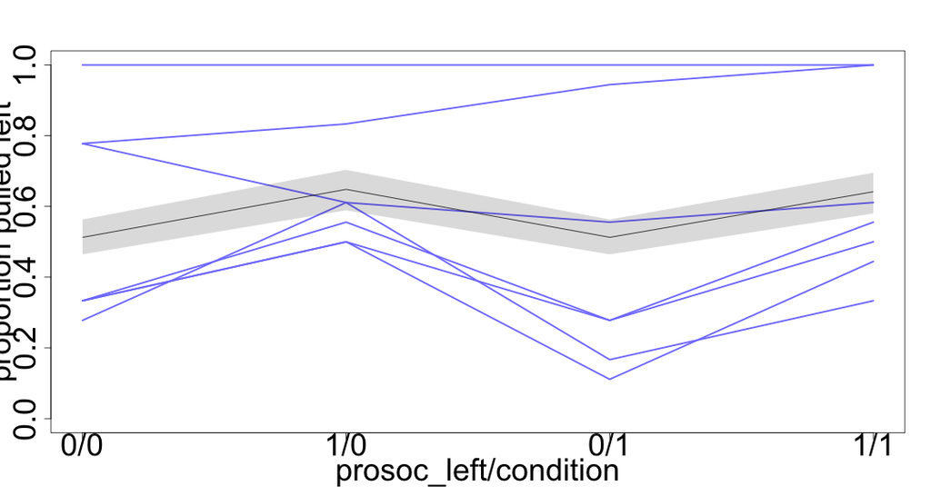

### Régression logistique

### MODÈLE - Vérification de la prédiction de MAP

Implémentation avec MAP2STAN

```r
df2 <- df1
df2$recipient <- NULL
# re-use map fit to get the formula
mod3stan <- map2stan( mod3 , data=df2 , iter=1e4 , warmup=1000 )
```

Estimation des paramètres

```r
precis(mod3stan)
```

```
     Mean StdDev lower 0.89 upper 0.89 n_eff Rhat
a    0.04   0.12      -0.15       0.24  4843    1
bp   0.61   0.22       0.27       0.97  4361    1
bpC -0.09   0.26      -0.50       0.34  4899    1
```

> Les résultats sont identiques à ceux obtenus avec MAP

### Régression logistique

### MODÈLE - Visualisation des estimations des paramètres

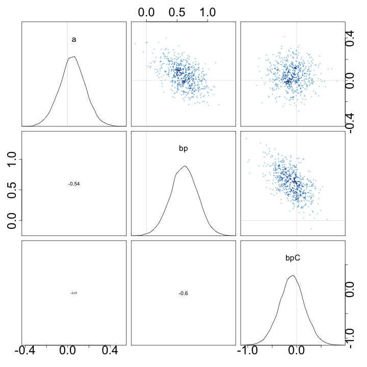

```r
pairs(mod3stan, cex.axis = 3, cex.label = 5)
```

### Peut-on capturer cette tendance pour un coté ?

L'objectif est d'isoler cet effet qui est masquant au regard de notre centre d'intérêt, la prosocialité.

### Régression logistique

### MODÈLE - Théorique

> \[ \begin{align} L_{i} &\sim \mathrm{Binomial}(1, p_{i}) \\ logit(p_{i}) &= \alpha{actor[i]} + (\beta_P +\beta_{PC}~C_{i})~ P_i\\ \alpha{actor} &\sim \mathrm{Normal}(0,10) \\ \beta_P &\sim \mathrm{Normal}(0,10) \\ \beta_{PC} &\sim \mathrm{Normal}(0,10) \\ \end{align} \]

On a donc un intercept unique pour chaque chimpanzé.

### Régression logistique

### MODÈLE - Implémentation

```r
mod4_2 <- map2stan(alist(
    pulled_left ~ dbinom(1, p) ,
    logit(p) <- a[actor] + (bp + bpC * condition) * prosoc_left,
    a[actor] ~ dnorm(0, 10),
    bp ~ dnorm(0, 10),
    bpC ~ dnorm(0, 10) ),
    data = df2, chains = 2, iter = 2500, warmup = 500)
```

### Régression logistique

### MODÈLE - Résultats

```r
precis(mod4_2, depth = 2)
```

```
      Mean StdDev lower 0.89 upper 0.89 n_eff Rhat
a[1] -0.74   0.28      -1.18      -0.29  2504    1
a[2] 11.07   5.50       3.31      18.46  1352    1
a[3] -1.05   0.28      -1.48      -0.60  2409    1
a[4] -1.06   0.29      -1.49      -0.57  3296    1
a[5] -0.75   0.27      -1.18      -0.31  2493    1
a[6]  0.22   0.27      -0.23       0.62  2550    1
a[7]  1.81   0.40       1.20       2.47  4000    1
bp    0.85   0.26       0.41       1.24  1974    1
bpC  -0.14   0.31      -0.63       0.33  2293    1
```

### Régression logistique

### MODÈLE - Visualisation

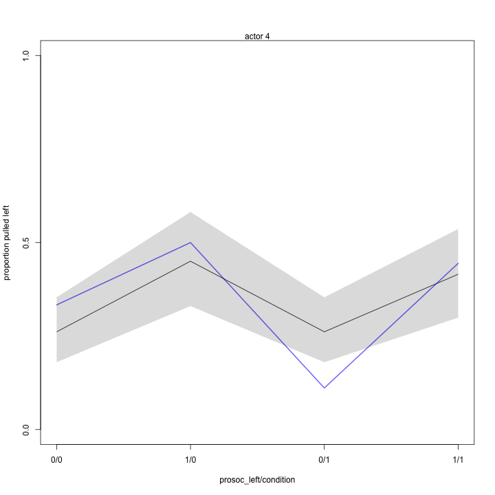

### Planning

## Cours

Cours 1: Introduction à l'inférence bayésienne

Cours 2: Modèle beta-binomial

Cours 3 & 4: Modèle de régression linéaire

Cours 5: Markov Chain Monte Carlo

**Cours 6: Modèle linéaire généralisé**

Cours 7: Comparaison de modèles

Cours 8: Modèles multi-niveaux

Cours 9: Introduction à `brms`

Cours 10: Data Hackaton

## Plan

- Introduction
- Régression logistique
- **Régression binomiale aggrégée**

### Régression binomiale aggrégée

### DATA : Admission à l'université

```r
library(rethinking)
data(UCBadmit)

(df2 <- UCBadmit)
```

```
   dept applicant.gender admit reject applications
1     A             male   512    313          825
2     A           female    89     19          108
3     B             male   353    207          560
4     B           female    17      8           25
5     C             male   120    205          325
6     C           female   202    391          593
7     D             male   138    279          417
8     D           female   131    244          375
9     E             male    53    138          191
10    E           female    94    299          393
11    F             male    22    351          373
12    F           female    24    317          341
```

Ces données représentent les candidatures à Berkeley, dans 6 département différents, classées par genre.

Chaque candidature est acceptée ou rejetée (valeur 0/1)… et les résultats sont aggrégés par département et par genre.

### QUESTION : Existe-t-il un biais de recrutement lié au genre dans ces données ?

### Régression binomiale aggrégée

### MODÈLE - Théorique

On va construire un modèle de la décision d'admission en prenant comme prédicteur le genre.

> \[ \begin{align} admit_{i} &\sim \mathrm{Binomial}(n_i,p_i) \\ logit(p_i) &= \alpha + \beta_m \cdot m_i \\ \alpha &\sim Normal(0,10) \\ \beta_m &\sim Normal(0,10) \end{align} \]

### Les Variables :

- \( admit_i \) Le nombre de candidatures acceptées (*admit*)
- \( n_i \) Le nombre total de candidatures (*applications*)
- \( m_i \) Le genre (*1 = male*)

### Régression binomiale aggrégée

### MODÈLE - Implémentation

On construit un modèle de la décision d'admission avec comme prédicteur le genre

```r
# dummy-coding
df2$male <- ifelse(df2$applicant.gender == "male", 1, 0)

mod4 <- map(alist(
    admit ~ dbinom(applications, p),
    logit(p) <- a + bm * male,
    a ~ dnorm(0, 10),
    bm ~ dnorm(0, 10) ),
    data = df2
    )
```

Pour évaluer l'overfiting du modèle mod4, on construit également le modèle de la décision d'admission mais sans prédicteur.

```r
mod5 <- map(alist(
    admit ~ dbinom(applications, p),
    logit(p) <- a ,
    a ~ dnorm(0, 10) ),
    data = df2)
```

### Régression binomiale aggrégée

### MODÈLE - Comparaison des modèles

```r
compare(mod4, mod5)
```

```
       WAIC pWAIC dWAIC weight    SE   dSE
mod4 5954.7   1.9   0.0      1 34.93    NA
mod5 6046.4   1.0  91.7      0 29.96 19.12
```

Cette comparaison suggère que la variable deprédiction compte beaucoup. Vérifions-le.

```r
precis(mod4)
```

```
    Mean StdDev  5.5% 94.5%
a  -0.83   0.05 -0.91 -0.75
bm  0.61   0.06  0.51  0.71
```

Être du genre masculin semble être un avantage ! Le rapport des probabilités est de \( exp(0,61) \) soit environ 1,84.

### Régression binomiale aggrégée

### MODÈLE - Interprétation des résultats

Calculons la différence de probabilité d'admission entre hommes et femmes.

```r
post <- extract.samples(mod4)
p.admit.male <- logistic(post$a + post$bm)
p.admit.female <- logistic(post$a)
diff.admit <- p.admit.male - p.admit.female
quantile(diff.admit, c(0.025, 0.5, 0.975) )
```

```
     2.5%       50%     97.5%
0.1137198 0.1414919 0.1693498
```

L'estimation mediane de l'avantage d'être un homme est de 14%.

### Régression binomiale aggrégée

### MODÈLE - Visualisation

Avant de conclure, visualisons les predictions du modèle par département.

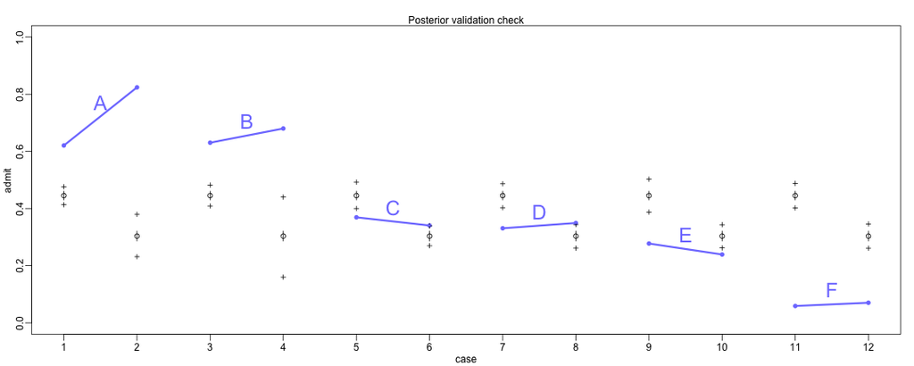

Les prédictions sont très mauvaises : Il n'y a que deux départements pour lesquels les femmes ont de moins bonnes prédictions que les hommes (C et E).

### Régression binomiale aggrégée

### MODÈLE - Analyse du problème

**\( \rightarrow~ \) Le problème est double :**

- Les hommes et les femmes ne candidatent pas aux mêmes départements
- Les départements n'ont pas tous les mêmes effectifs

### C'est le paradoxe de Simpson

**\( \rightarrow~ \) Remarque :**

- La distribution postérieure seule n'aurait pas permis de détecter ce problème
- C'est l'étude des prédictions du modèle qui nous a permis de mettre le doigt sur le problème

**\( \rightarrow~ \) Solution :**

## Chercher les disparités hommes-femmes pour chaque département

### Régression binomiale aggrégée

### MODÈLE - Théorique

On construit un modèle de la décision d'admission avec un taux d'admission pour les femmes unique par département (intercept) et une différence moyenne pour les hommes.

> \[ \begin{align} admit_{i} &\sim \mathrm{Binomial}(n_i,p_i) \\ logit(p_i) &= \alpha_{Dept[i]} + \beta_m~m_i \\ \alpha_{Dept} &\sim Normal(0,10) \\ \beta_m &\sim Normal(0,10) \end{align} \]

### Régression binomiale aggrégée

### MODÈLE - Implémentation

Modèle sans prédicteur

```r
# Make index

df2$dept_id <- coerce_index(df2$dept)

# model with unique intercept for each dept

mod6 <- map(alist(
    admit ~ dbinom(applications, p),
    logit(p) <- a[dept_id],
    a[dept_id] ~ dnorm(0, 10) ),
    data = df2
    )
```

Modèle avec prédicteur

```r
# model with male difference as well

mod7 <- map(alist(
    admit ~ dbinom( applications, p),
    logit(p) <- a[dept_id] + bm * male,
    a[dept_id] ~ dnorm(0, 5),
    bm ~ dnorm(0, 5) ),
    data = df2
    )
```

### Régression binomiale aggrégée

### MODÈLE - Comparaison des modèles

```r
compare(mod4, mod5, mod6, mod7)
```

```
       WAIC pWAIC dWAIC weight    SE   dSE
mod6 5200.8   5.9   0.0   0.54 57.08    NA
mod7 5201.1   6.8   0.3   0.46 56.99  2.47
mod4 5954.8   2.0 754.1   0.00 35.00 48.52
mod5 6046.1   0.9 845.4   0.00 29.96 52.38
```

Remarque :

- Les nouveaux modèles sont meilleurs
- Le nouveau modèle sans prédicteur est meilleur que celui avec prédicteur

### Régression binomiale aggrégée

### MODÈLE - Interprétation

```r
precis(mod7, depth = 2)
```

```
      Mean StdDev  5.5% 94.5%
a[1]  0.68   0.10  0.52  0.84
a[2]  0.64   0.12  0.45  0.82
a[3] -0.58   0.07 -0.70 -0.46
a[4] -0.61   0.09 -0.75 -0.48
a[5] -1.06   0.10 -1.21 -0.90
a[6] -2.62   0.16 -2.87 -2.37
bm   -0.10   0.08 -0.23  0.03
```

Maintenant, la prédiction pour `bm` va dans l'autre sens.  
L'échelle de proportion de chances est de \( exp(-0,1) \) soit environ 0,9.

### Régression binomiale aggrégée

### MODÈLE - Visualisation

Visualisons les prédictions postérieures de notre modèle.

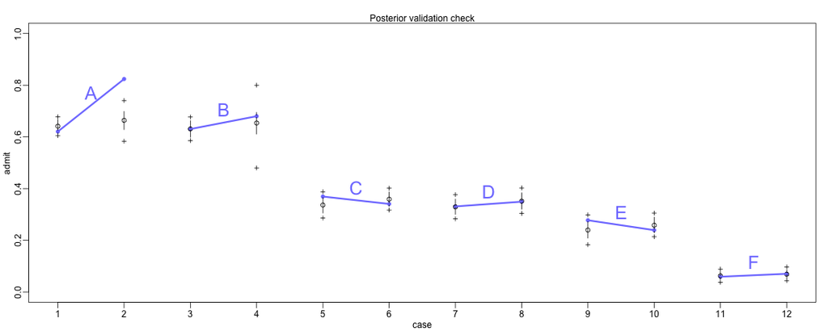